# Maurer Project

## Categories

- politics / activism
- public defender
- sue tobacco companies
- wills & testaments / country lawyer
- Big Law
- environment
- clerking / scholarly research

These are the buckets for our histograms. They not only come with salary expectations but effectiveness / achievement in other directions.

We particularly want to detect law students who end up working outside law in low-paying unrelated jobs, or those who end up working in law in low-paying occupations (paralegal, contract work, etc).

## Brian Z Tamanaha

Tamanaha, in *Failing Law Schools*, claims 50% non-response rates and various shady techniques are used to massage matriculant-facing salary figures.

- https://www.youtube.com/watch?v=gjx3JwR1F4s [3:37]

[interactive chart not shown]

- http://jle.aals.org/cgi/viewcontent.cgi?article=1072&context=home > It is clear that law school is expensive. The book tells the story of how it came to be so expensive in an engaging, almost breathtaking way.

- https://law.wustl.edu/faculty_profiles/profiles.aspx?id=7287
- https://balkin.blogspot.com/2010/06/wake-up- fellow-law-professors-to.html

### `LinkedIn` as a data source

LinkedIn’s bias is in the right direction: those looking for a job are more likely to be on it, than the gainfully-employed.

## Getting the lawyers’ perspective

- https://balkin.blogspot.com/2010/06/wake-up-fellow-law-professors-to.html > Their complaint is that non-elite law schools are selling a fraudulent bill of goods. Law schools advertise deceptively high rates of employment and misleading income figures. Many graduates can’t get jobs. Many graduates end up as temp attorneys working for $15 to $20 dollars an hour on two week gigs, with no benefits. The luckier graduates land jobs in government or small firms for maybe $45,000, with limited prospects for improvement. A handful of lottery winners score big firm jobs. […] This dismal situation was not created by the current recession—which merely spread the pain up the chain into the lower reaches of elite schools. This has been going on for years. The law graduates posting on these sites know the score. They know that law schools pad their employment figures—96% employed—by counting as “employed” any job at all, legal or non-legal, including part time jobs, including unemployed graduates hired by the school as research assistants (or by excluding unemployed graduates “not currently seeking” a job, or by excluding graduates who do not supply employment information). They know that the gaudy salary numbers advertised on the career services page—“average starting salary $125,000 private full time employment”—are actually calculated based upon only about 25% of the graduating class (although you can’t easily figure this out from the information provided by the schools). They know all this because they know of too many classmates who didn’t get jobs or who got low paying jobs—the numbers don’t jibe with their first hand knowledge. They know the score now. But they didn’t know it when they first applied to law school. […]
- www.lawyersgunsmoneyblog.com/
- http://abovethelaw.com/tag/law-blogs/
- http://www.fed-soc.org/publications/detail/are-american-law-schools-failing-an-exchange-between-brian-tamanaha-harold-see
- https://www.washingtonpost.com/opinions/book-review-failing-law-schools-by-brian-z-tamanaha/2012/08/03/e7054c9c-c6df-11e1-916d-a4bc61efcad8_story.html?utm_term=.56aec2d034af “Thousands of liberal arts BAs grew up on those assumptions. “Everyone is pre-law,” journalist Michael Kinsley quipped, “until the day they enter medical school.” A JD himself, Kinsley knew whereof he spoke.”
- http://www.wsj.com.proxyiub.uits.iu.edu/articles/SB10001424052702304458604577486623469958142 = http://kg6ek7cq2b.search.serialssolutions.com.proxyiub.uits.iu.edu/?genre=article&atitle=Law%20grads%20face%20brutal%20job%20market&title=The%20Wall%20Street%20Journal%20Eastern%20Edition&issn=00999660&isbn=&volume=&issue=&date=20120625&aulast=Palazzolo,%20Joe&spage=1&pages=1-1&sid=EBSCO:General%20OneFile:edsgcl.294351737

> Members of the law-school class of 2011 had little better than a 50-50 shot of landing a job as a lawyer within nine months of receiving a degree, according to a Wall Street Journal analysis of new data that provides the most detailed picture yet of the grim market for law jobs. Under pressure from disillusioned graduates and some professors, the American Bar Association for the first time released a tally of the previous year’s graduates who have secured full-time, permanent jobs as lawyers. Until recently, the ABA required law schools to report only general data about how their graduates fared, such as how many were employed full-time or part-time in any kind of job, whether or not it required a law degree. The numbers suggest the job market for law grads is worse than previously thought. Nationwide, only 55% of the class of 2011 had full-time, long-term jobs that required a law degree nine months after graduation. The ABA defines “long-term” jobs as those that don’t have a term of less than one year. Of course, it isn’t uncommon for people to attend law school to advance their career without practicing law. Several law-school deans cautioned against placing too much emphasis on jobs requiring a law degree. Nationally, 8% of 2011 graduates were said to be in full-time, long-term jobs for which a law degree was preferred but not required, according to the Journal’s data analysis. Another 4% were employed in full-time, long-term positions for which professional training was required but for which a law degree offered no advantage.
- http://thirdtierreality.blogspot.com/
- http://esqnever.blogspot.com/
- http://lawschoolscam.blogspot.com/
- http://www.notolawschool.com/
- http://temporaryattorney.blogspot.com/
- https://balkin.blogspot.com/2008/01/why-interdisciplinary-movement-in-legal.html
- https://newrepublic.com/article/110315/failing-law-schools-how-to-fix-legal-education-brian-tamanaha-harvard-yale > the American Bar Association (ABA) decides which law schools can be accredited, and it requires that law schools primarily employ tenured or tenure-track professors. Sixty-five percent of professors in American universities are employed in positions not eligible for tenure, but any law school that tried to match that proportion could lose its accreditation. As a result, law schools shoulder the cost of a permanent crop of highly compensated professors. Tuition at public law schools increased 200 percent, and at private law schools by 179 percent, throughout the 1980s. In the 1990s, law student debt quadrupled. Meanwhile, the job market for lawyers has contracted dramatically, and without any immediate prospect for improvement. In this climate, lenders might be less inclined to lend—except that the federal government has emerged as a major enabler. If your income is meager enough to make it difficult for you to pay back your law school loans, your monthly payment will be lowered, and the federal government will help. After twenty-five years for most lawyers and ten years for those working in public-service jobs, any remaining law school loan balance will be forgiven—paid for by the federal government and the American taxpayer. (This applies to some other professionals, as well, like doctors, but lawyers, on the whole, are the professionals who face the hardest time paying back their rising debt.) […] law schools and the legal community convey that the status of the school is quite important, and students are already inclined to believe this. Enrollment choices are therefore too often made according to marginal differences in the status of the school rather than on the quality of the educational product and the cost at which it provides it. […] Since 2010, applications to law schools are down nearly 25 percent. Only about two-thirds of law school graduates are employed in jobs requiring passage of the bar examination, and 12 percent of graduates are unemployed. […] urrent and future members of the legal community are more status-driven than almost any other professional community (witness that eight of nine Supreme Court Justices graduated from Harvard or Yale law schools
- `http://www.nytimes.com/2011/11/20/business/after-law-school-associates-learn-to-be-lawyers.html?_r=2&hp=&pagewanted=all&`
- http://www.americanbar.org/groups/legal_education/resources/accreditation.html
- http://grad-schools.usnews.rankingsandreviews.com/best-graduate-schools/top-law-schools/law-rankings †

† easy data page to make: re-use US News data fields and allow people to re-weight (thus you see how important the arbitrary imposition of a fixed weighting scheme is, to rank)

# Salary estimates

- indeed
- glass door
- dictionary of occupational titles

# getting names of law students

http://gradedistribution.registrar.indiana.edu/reports.php?school=LAW&term=4135&rept=1&result=HTM

# other desiderata

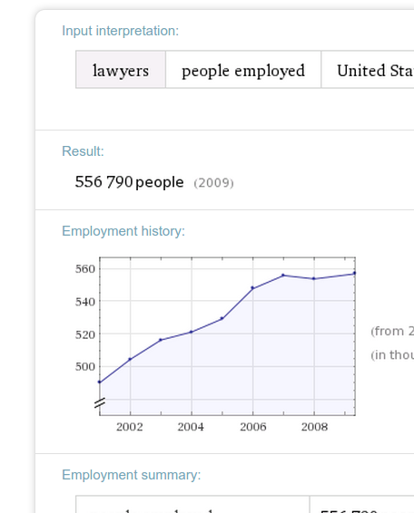